# NRES 776 Lab 9

GLM with single predictor

Sunny Tseng

## Our schedule today

- Discussion paper presentation (50 min)
- Binomial regression with single continuous $x$ (15 min)
- Lab intro - Poisson regression with single predictor variable (10 min)
- Lab intro - Binomial regression with single predictor variable (10 min)
- Practice (60 min)

# Discussion paper presentation

- Olivia Wilson
- Tina Watters
- Brett Gandy

# Binomial regression

## Research question (1 continuous x)

A survey was done on 50 islands for the incidence of a bird species Grasshopper Warbler. Researchers want to know whether the incidence is related to the area and/or the isolation level of the islands.

### Use long format as input

```
# A tibble: 50 × 3
   incidence  area isolation
   <fct>     <dbl> <fct>
 1 1          7.93 low
 2 0          1.92 high
 3 1          2.04 median
 4 0          4.78 median
 5 0          1.54 median
 6 1          7.37 low
 7 1          8.60 low
 8 0          2.42 high
 9 1          6.40 median
10 1          7.20 median
# ℹ 40 more rows
```

### Take a look at the relationship

```
# A tibble: 3 × 3
  proportion total mean_area
       <dbl> <int>     <dbl>
1      1        15      6.03
2      0.636    22      3.93
3      0        13      3.01
```

## Model formulation

$$logit(p_i) = \beta_0 + \beta_1 x_{1i}$$

```r
incidence_binom <- glm(formula = incidence ~ area,
                       data = data_long,
                       family = "binomial")
incidence_binom %>% summary
```

```
Call:
glm(formula = incidence ~ area, family = "binomial", data = data_long)

Coefficients:
            Estimate Std. Error z value Pr(>|z|)
(Intercept)  -2.1554     0.7545  -2.857 0.004278 **
area          0.6272     0.1861   3.370 0.000753 ***
---
Signif. codes:  0 '***' 0.001 '**' 0.01 '*' 0.05 '.' 0.1 ' ' 1

(Dispersion parameter for binomial family taken to be 1)

    Null deviance: 68.029  on 49  degrees of freedom
Residual deviance: 50.172  on 48  degrees of freedom
AIC: 54.172

Number of Fisher Scoring iterations: 5
```

## Coef. interpretation

- For island with area as 0 (baseline):

$$logit(p_i) = log(\frac{p_i}{1-p_i})= \beta_0$$

$$\frac{p_i}{1-p_i} = Odd(p_i) = exp(\beta_0) = exp(-2.15) = 0.11$$

- The odd for the intercept is not often interpreted by itself.

## Coef. interpretation (con’d)

- For island with non-0 area:

$$logit(p_i) = \beta_0 + \beta_1 x_{1i}$$

$$logit(p_i') = \beta_0 + \beta_1 (x_{1i} + 1)$$

$$logit(p_i') - logit(p_i) = \beta_1 = log(\frac{Odd(p_i')}{Odd(p_i)})$$

$$\frac{Odd(p_i')}{Odd(p_i)} = exp(\beta_1) = exp(0.62) = 1.87$$

- For one unit increase in `area`, the odds of the bird species being present increase by a factor of 1.87.

## Output interpretation

### Odd ratio (OR)

- $OR = 1$, no difference between groups
- $OR < 1$, treatment decreases odds
- $OR > 1$, treatment increases odds

### R output

- **Intercept (-2.15)**: The odd of the bird being present on 0 area island is $exp(-2.15)$
- **area (0.62)**: For one unit increase in `area`, the odds of the bird species being present increase by a factor of $exp(0.62)$
- **Dispersion parameter (1)**: wonderful. Need to consider other methods if dispersion larger than 1 (over-dispersion) or smaller than 1 (under-dispersion)
- **AIC (54.172)**: Can be used to compare the goodness of fit between models

## Model goodness of fit: Likelihood ratio test

```r
incidence_binom_null <- glm(formula = incidence ~ 1,
                            data = data_long,
                            family = "binomial")
```

$H_0$: The model performance is the same as a null model (making predictions by chance)

$H_1$: The model performance is significantly different comparing to a null model

- Use `lrtest()` function in the `lmtest` package

```r
lrtest(incidence_binom, incidence_binom_null)
```

```
Likelihood ratio test

Model 1: incidence ~ area
Model 2: incidence ~ 1
  #Df  LogLik Df  Chisq Pr(>Chisq)
1   2 -25.086
2   1 -34.015 -1 17.857  2.382e-05 ***
---
Signif. codes:  0 '***' 0.001 '**' 0.01 '*' 0.05 '.' 0.1 ' ' 1
```

## Model prediction

- Use `predict()` and specify `type = "response"` to get back transformed $y_i$

```r
incidence_p <- data_long %>%
  mutate(incidence_p = predict(incidence_binom, type = "response"))
incidence_p
```

```
# A tibble: 50 × 4
   incidence  area isolation incidence_p
   <fct>     <dbl> <fct>           <dbl>
 1 1          7.93 low             0.944
 2 0          1.92 high            0.279
 3 1          2.04 median          0.295
 4 0          4.78 median          0.699
 5 0          1.54 median          0.233
 6 1          7.37 low             0.922
 7 1          8.60 low             0.962
 8 0          2.42 high            0.346
 9 1          6.40 median          0.865
10 1          7.20 median          0.914
# ℹ 40 more rows
```

## Model visualization

```r
data_long %>%
  mutate(incidence = incidence %>% as.numeric() - 1) %>%
  ggplot(aes(x = area, y = incidence), data = .) +
  geom_jitter(width = 0, height = 0.05) +
  geom_smooth(method =  "glm",
              method.args = list(family = "binomial"),
              se = FALSE) +
  labs(y = "Probability of incidence", x = "Area of an island")
```

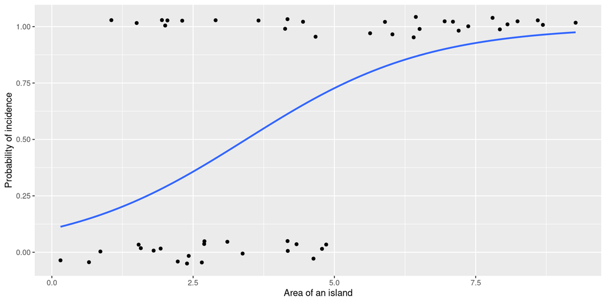

## Model visualization

```r
ggplot(aes(x = isolation, y = incidence_p),
       data = incidence_p) +
  geom_boxplot() +
  labs(y = "Probability of incidence", x = "Isolation level of island")
```

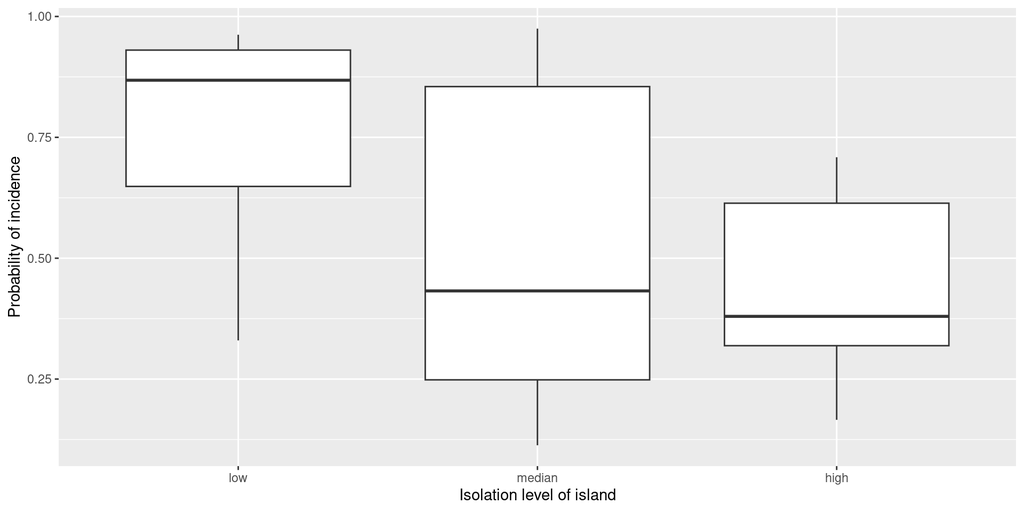

# Lab 9 - GLM with single predictor

## Get the lab assignment file

1. Download the file on Moodle `Lab 9 - assignment file`. You should get a `.Rmd` file after downloading
2. Get the two data set, one crab data set and on titanic data set
3. Create a `R project` folder, and put `.Rmd`, two your data sets in the same folder

### Run R markdown

1. Open the R project, open the `.Rmd` file
2. Install and load `rmarkdown` package

```r
install.packages("rmarkdown")
library(rmarkdown)
```

3. Click `knit` and you should get a `html` output
4. You are all set!

## Submission

### Due next Wednesday 23:59 pm, Moodle

- File name and type (NRES776_*firstname*_*lastname*_lab_9.**html**)